# Linear Models- continued

Author

Dr. Niloufar Abourashchi and Dr. Thomas Honnor

## Today’s Agenda

- Investigation of linear models for high school data
- Comparing models
- Overfitting
- Assessment 1 release

```r
library(tidyverse)
```

- Read data, convert categorical variables to factors with descriptive labels, and remove the ‘female’ column.

```r
female_labels <- c("male","female")
race_labels <- c("hispanic", "asian", "african-american", "white")
ses_labels <- c("low", "middle", "high")
schtyp_labels <- c("public","private")
prog_labels <- c("general", "academic", "vocational")
highschool <- read_csv("hsb2.csv", col_types = "dfffffddddd") %>%
  mutate(gender = factor(female, levels = c(0,1), labels = female_labels),
         race = factor(race, levels = c(1,2,3,4), labels = race_labels),
         ses = factor(ses, levels = c(1,2,3), labels = ses_labels),
         schtyp = factor(schtyp, levels = c(1,2), labels = schtyp_labels),
         prog = factor(prog, levels = c(1,2,3), labels = prog_labels)) %>%
  select(-female)
glimpse(highschool)
```

```
Rows: 200
Columns: 11
$ id      <dbl> 70, 121, 86, 141, 172, 113, 50, 11, 84, 48, 75, 60, 95, 104, 3…
$ race    <fct> white, white, white, white, white, white, african-american, hi…
$ ses     <fct> low, middle, high, high, middle, middle, middle, middle, middl…
$ schtyp  <fct> public, public, public, public, public, public, public, public…
$ prog    <fct> general, vocational, general, vocational, academic, academic, …
$ read    <dbl> 57, 68, 44, 63, 47, 44, 50, 34, 63, 57, 60, 57, 73, 54, 45, 42…
$ write   <dbl> 52, 59, 33, 44, 52, 52, 59, 46, 57, 55, 46, 65, 60, 63, 57, 49…
$ math    <dbl> 41, 53, 54, 47, 57, 51, 42, 45, 54, 52, 51, 51, 71, 57, 50, 43…
$ science <dbl> 47, 63, 58, 53, 53, 63, 53, 39, 58, 50, 53, 63, 61, 55, 31, 50…
$ socst   <dbl> 57, 61, 31, 56, 61, 61, 61, 36, 51, 51, 61, 61, 71, 46, 56, 56…
$ gender  <fct> male, female, male, male, male, male, male, male, male, male, …
```

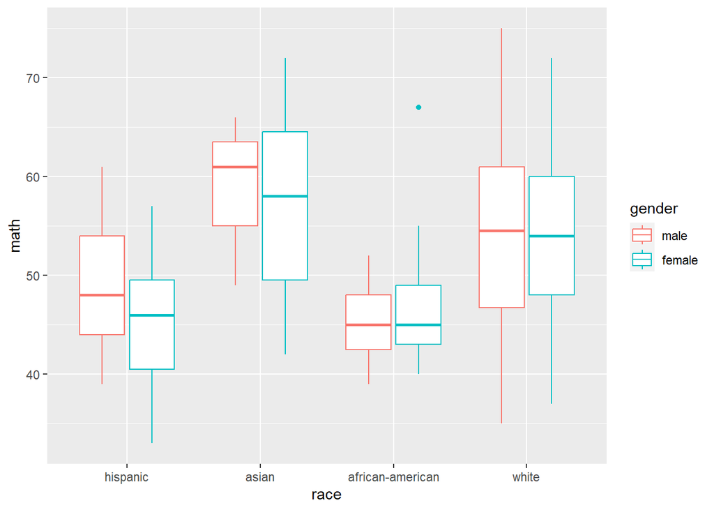

```r
highschool %>%
  ggplot(mapping=aes(y=math, x=race, color=gender)) +
  geom_boxplot()
```

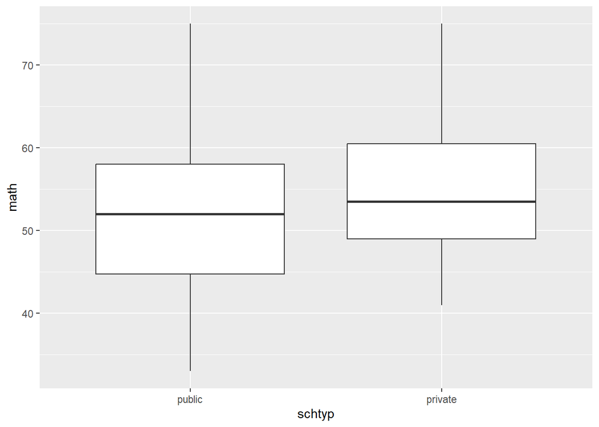

```r
highschool %>%
  ggplot(mapping=aes(y=math, x=schtyp)) +
  geom_boxplot()
```

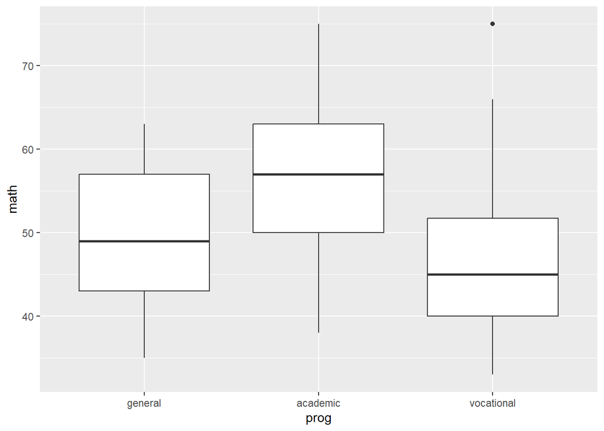

```r
highschool %>%
  ggplot(mapping=aes(y=math, x=prog)) +
  geom_boxplot()
```

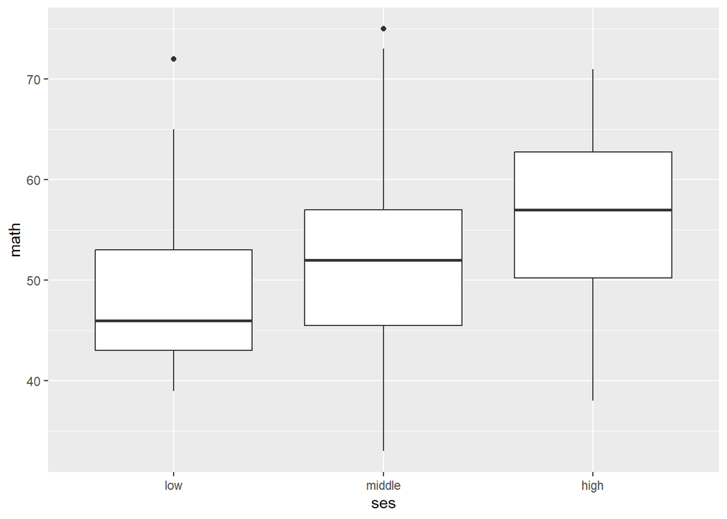

```r
highschool %>%
  ggplot(mapping=aes(y=math, x=ses)) +
  geom_boxplot()
```

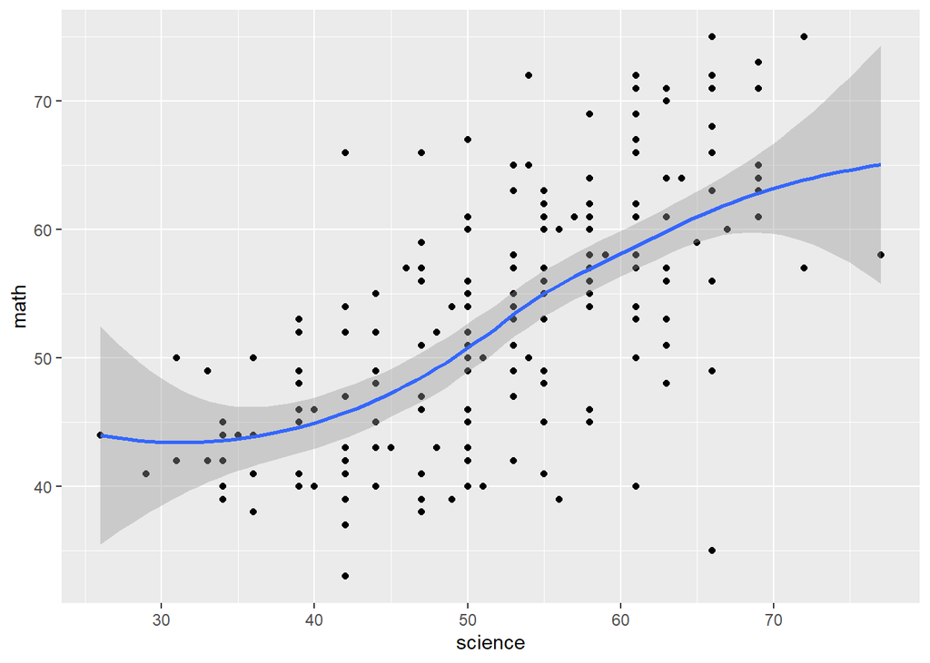

```r
highschool %>%
  ggplot(mapping=aes(y=math, x=science)) +
  geom_point() +
  geom_smooth()
```

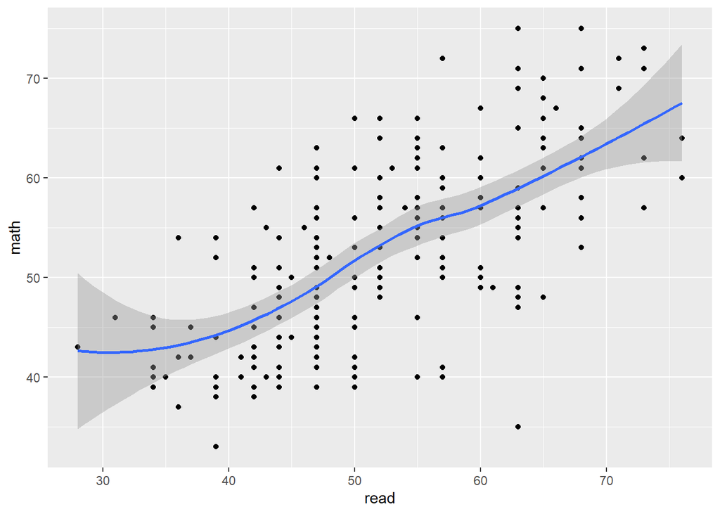

```r
highschool %>%
  ggplot(mapping=aes(y=math, x=read)) +
  geom_point() +
  geom_smooth()
```

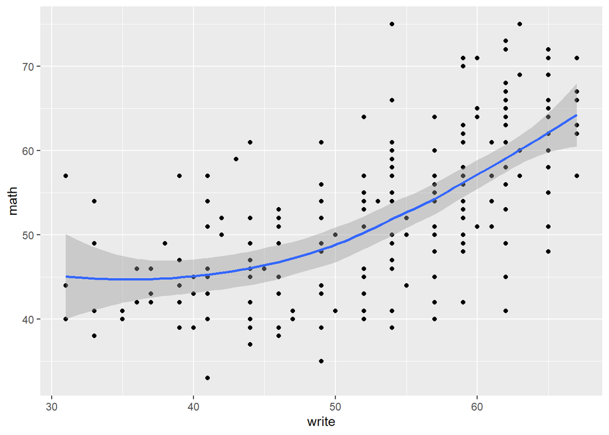

```r
highschool %>%
  ggplot(mapping=aes(y=math, x=write)) +
  geom_point() +
  geom_smooth()
```

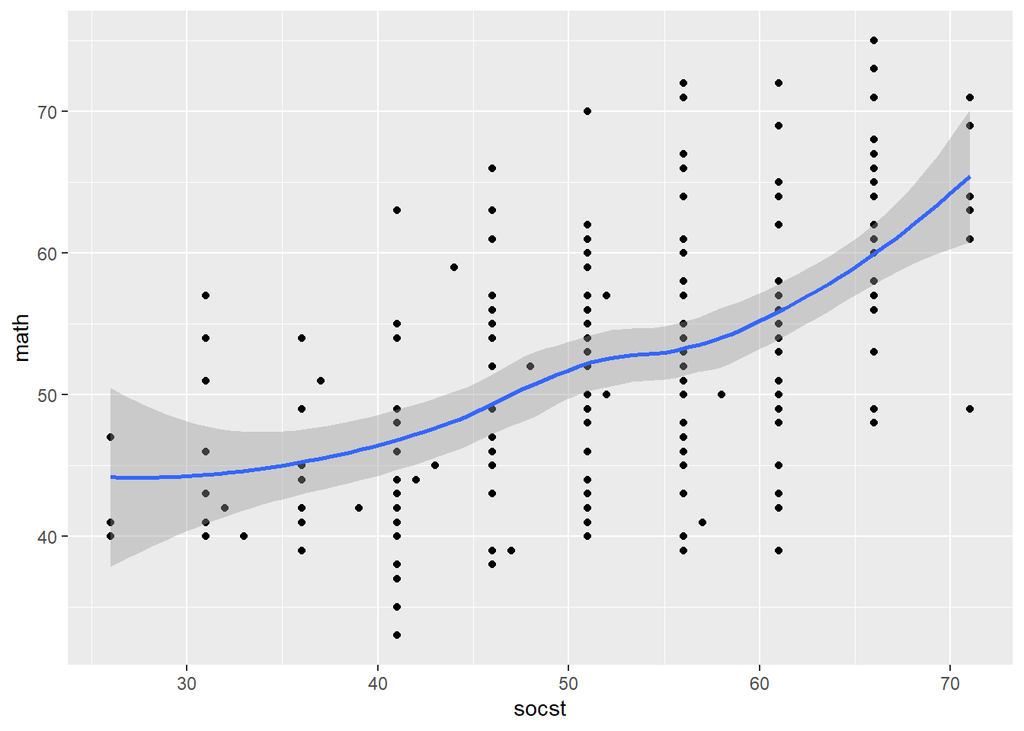

```r
highschool %>%
  ggplot(mapping=aes(y=math, x=socst)) +
  geom_point() +
  geom_smooth()
```

```r
library(GGally)
```

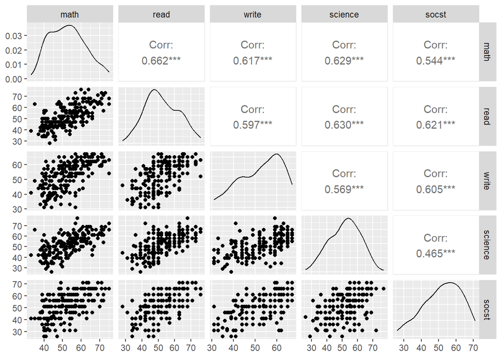

```r
highschool %>%
  select(math,read,write,science,socst) %>%
  ggpairs()
```

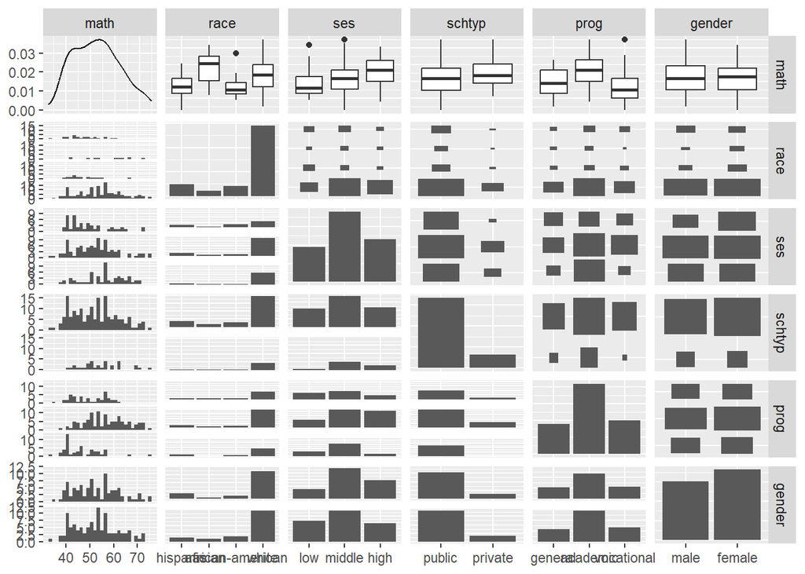

```r
highschool %>%
  select(math,race,ses,schtyp,prog,gender) %>%
  ggpairs()
```

```r
lm_read <- lm(math ~ read, data=highschool)
summary(lm_read)
```

```
Call:
lm(formula = math ~ read, data = highschool)

Residuals:
     Min       1Q   Median       3Q      Max
-24.1624  -5.1624  -0.4135   4.7775  16.4684

Coefficients:
            Estimate Std. Error t value Pr(>|t|)
(Intercept) 21.03816    2.58945   8.125 4.76e-14 ***
read         0.60515    0.04865  12.438  < 2e-16 ***
---
Signif. codes:  0 '***' 0.001 '**' 0.01 '*' 0.05 '.' 0.1 ' ' 1

Residual standard error: 7.037 on 198 degrees of freedom
Multiple R-squared:  0.4386,    Adjusted R-squared:  0.4358
F-statistic: 154.7 on 1 and 198 DF,  p-value: < 2.2e-16
```

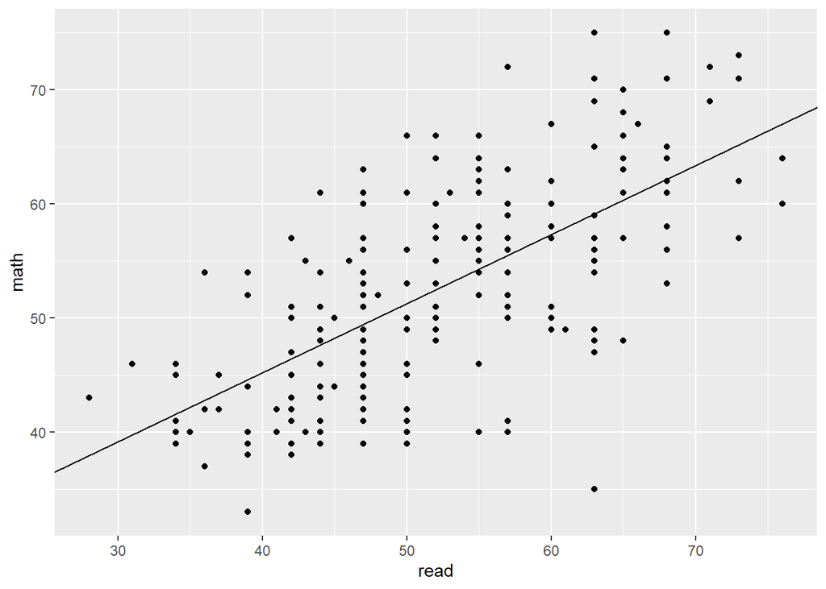

```r
# read in fit coefficients (intercept and slope)
B0 <- summary(lm_read)$coefficients[1]
B1 <- summary(lm_read)$coefficients[2]

# draw onto plot
ggplot(data=highschool,mapping=aes(y=math, x=read)) +
  geom_point() +
  geom_abline(intercept=B0, slope=B1)
```

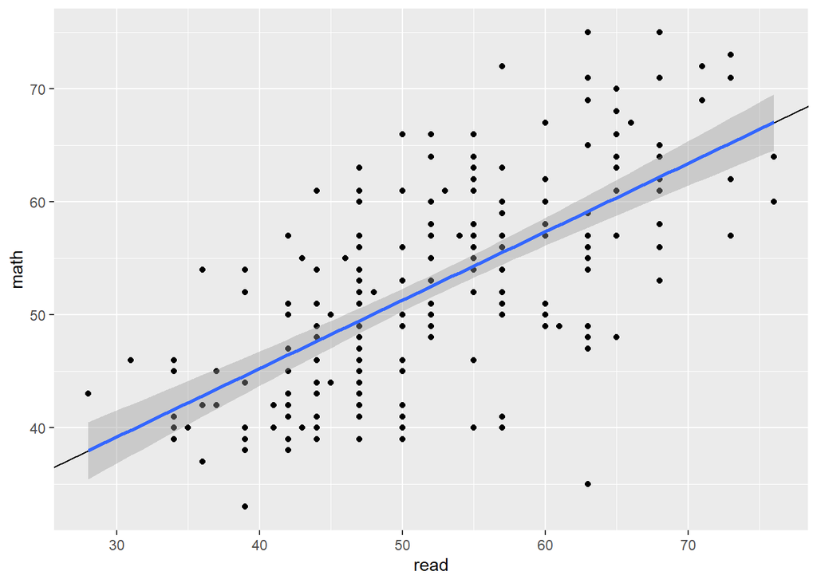

```r
B0 <- summary(lm_read)$coefficients[1]
B1 <- summary(lm_read)$coefficients[2]

ggplot(data=highschool,mapping=aes(y=math, x=read)) +
  geom_point() +
  geom_abline(intercept=B0, slope=B1) +
  geom_smooth(method=lm)
```

```r
#running geom_smooth with method=lm gives a better visualisation, more easily
```

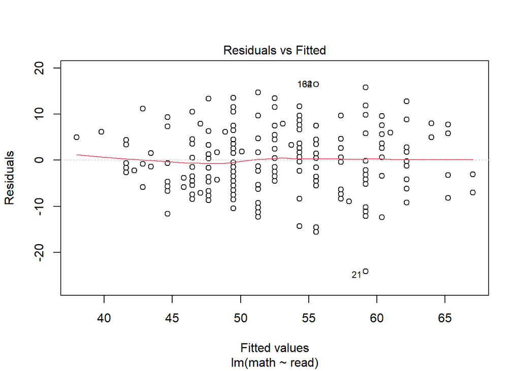

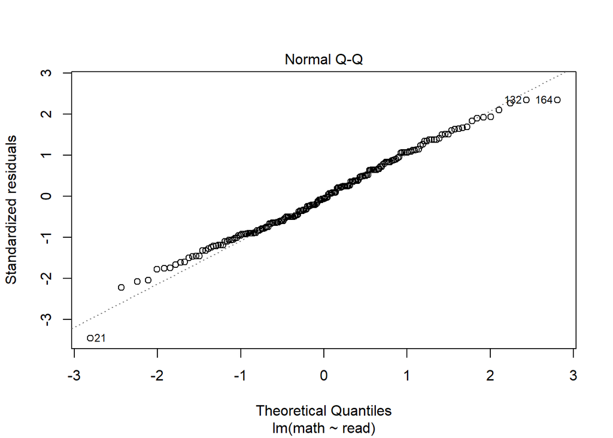

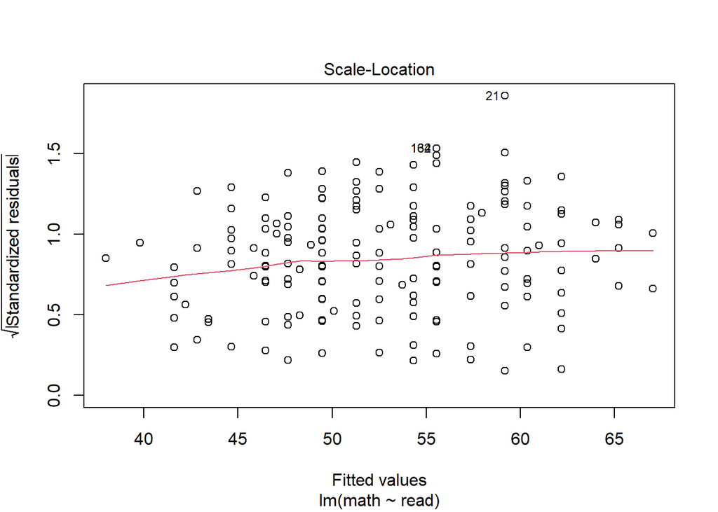

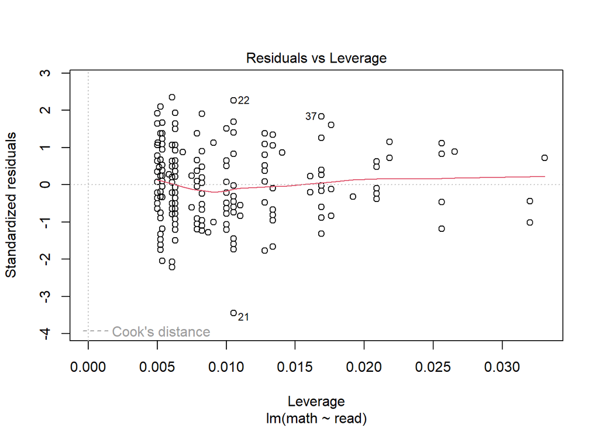

```r
# view diagnostic plots. no obvious trends in resdiuals that indicate major issues
plot(lm_read)
```

```r
lm_read_sci <- lm(math ~ read + science, data=highschool)
summary(lm_read_sci)
```

```
Call:
lm(formula = math ~ read + science, data = highschool)

Residuals:
     Min       1Q   Median       3Q      Max
-26.6673  -4.3116   0.2366   4.8017  16.7265

Coefficients:
            Estimate Std. Error t value Pr(>|t|)
(Intercept) 14.42079    2.70132   5.338 2.57e-07 ***
read         0.40269    0.05851   6.883 7.64e-11 ***
science      0.33147    0.06037   5.491 1.22e-07 ***
---
Signif. codes:  0 '***' 0.001 '**' 0.01 '*' 0.05 '.' 0.1 ' ' 1

Residual standard error: 6.57 on 197 degrees of freedom
Multiple R-squared:  0.5131,    Adjusted R-squared:  0.5082
F-statistic: 103.8 on 2 and 197 DF,  p-value: < 2.2e-16
```

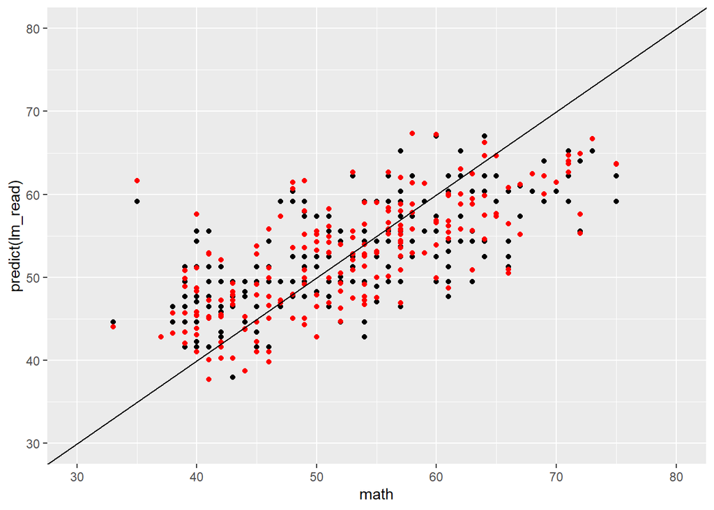

```r
ggplot(data = highschool) +
  geom_point(mapping=aes(x=math, y=predict(lm_read))) +
  geom_point(mapping=aes(x=math, y=predict(lm_read_sci)), color="red") +
  geom_abline(intercept = 0, slope = 1) +
  xlim(30,80) +
  ylim(30,80)
```

```r
lm_ses <- lm(math ~ ses, data=highschool)
summary(lm_ses)
```

```
Call:
lm(formula = math ~ ses, data = highschool)

Residuals:
     Min       1Q   Median       3Q      Max
-19.2105  -6.2105  -0.1724   5.7895  22.8298

Coefficients:
            Estimate Std. Error t value Pr(>|t|)
(Intercept)   49.170      1.321  37.220  < 2e-16 ***
sesmiddle      3.040      1.615   1.882 0.061254 .
seshigh        7.002      1.777   3.939 0.000113 ***
---
Signif. codes:  0 '***' 0.001 '**' 0.01 '*' 0.05 '.' 0.1 ' ' 1

Residual standard error: 9.057 on 197 degrees of freedom
Multiple R-squared:  0.07484,   Adjusted R-squared:  0.06544
F-statistic: 7.968 on 2 and 197 DF,  p-value: 0.0004704
```

```r
lm_read_ses <- lm(math ~ read + ses, data=highschool)
summary(lm_read_ses)
```

```
Call:
lm(formula = math ~ read + ses, data = highschool)

Residuals:
     Min       1Q   Median       3Q      Max
-23.8603  -4.8669  -0.5301   4.6945  17.7507

Coefficients:
            Estimate Std. Error t value Pr(>|t|)
(Intercept) 21.06176    2.66220   7.911 1.83e-13 ***
read         0.58224    0.05089  11.441  < 2e-16 ***
sesmiddle    1.11756    1.26501   0.883    0.378
seshigh      2.21422    1.44189   1.536    0.126
---
Signif. codes:  0 '***' 0.001 '**' 0.01 '*' 0.05 '.' 0.1 ' ' 1

Residual standard error: 7.031 on 196 degrees of freedom
Multiple R-squared:  0.4453,    Adjusted R-squared:  0.4368
F-statistic: 52.45 on 3 and 196 DF,  p-value: < 2.2e-16
```

We performed two ANOVA tests:

## Comparing `lm_read` and `lm_read_ses`

```r
anova(lm_read, lm_read_ses)
```

```
Analysis of Variance Table

Model 1: math ~ read
Model 2: math ~ read + ses
  Res.Df    RSS Df Sum of Sq      F Pr(>F)
1    198 9805.0
2    196 9688.2  2    116.86 1.1821 0.3088
```

| Model | Res.Df | RSS | Df | Sum of Sq | F | Pr(>F) |
| --- | --- | --- | --- | --- | --- | --- |
| lm_read | 198 | 9805.0 |  |  |  |  |
| lm_read_ses | 196 | 9688.2 | 2 | 116.86 | 1.1821 | 0.3088 |

## Comparing `lm_ses` and `lm_read_ses`

```r
anova(lm_ses, lm_read_ses)
```

```
Analysis of Variance Table

Model 1: math ~ ses
Model 2: math ~ read + ses
  Res.Df     RSS Df Sum of Sq     F    Pr(>F)
1    197 16158.7
2    196  9688.2  1    6470.5 130.9 < 2.2e-16 ***
---
Signif. codes:  0 '***' 0.001 '**' 0.01 '*' 0.05 '.' 0.1 ' ' 1
```

[output not shown]

```r
anova(lm_read,lm_read_ses)
```

```
Analysis of Variance Table

Model 1: math ~ read
Model 2: math ~ read + ses
  Res.Df    RSS Df Sum of Sq      F Pr(>F)
1    198 9805.0
2    196 9688.2  2    116.86 1.1821 0.3088
```

```r
anova(lm_ses,lm_read_ses)
```

```
Analysis of Variance Table

Model 1: math ~ ses
Model 2: math ~ read + ses
  Res.Df     RSS Df Sum of Sq     F    Pr(>F)
1    197 16158.7
2    196  9688.2  1    6470.5 130.9 < 2.2e-16 ***
---
Signif. codes:  0 '***' 0.001 '**' 0.01 '*' 0.05 '.' 0.1 ' ' 1
```

- The code `lm_all <- lm(math ~ ., data=highschool)` creates a linear regression model that predicts the math scores (math) of students based on all other available variables in the highschool dataset.
- In this context, `math ~ .` indicates that all other columns in the highschool data frame are used as predictors for the math scores.

```r
lm_all <- lm(math ~ ., data=highschool)
summary(lm_all)
```

```
Call:
lm(formula = math ~ ., data = highschool)

Residuals:
     Min       1Q   Median       3Q      Max
-22.2553  -4.0316  -0.2929   4.7013  14.5877

Coefficients:
                     Estimate Std. Error t value Pr(>|t|)
(Intercept)          11.97130    3.33606   3.588 0.000426 ***
id                    0.02296    0.01654   1.389 0.166654
raceasian             4.25082    2.34550   1.812 0.071557 .
raceafrican-american -0.96673    1.95298  -0.495 0.621185
racewhite            -1.91976    2.31956  -0.828 0.408941
sesmiddle             0.31934    1.19143   0.268 0.788973
seshigh               0.22222    1.34901   0.165 0.869340
schtypprivate        -1.69971    1.61058  -1.055 0.292644
progacademic          3.70713    1.18212   3.136 0.001993 **
progvocational       -0.04816    1.32694  -0.036 0.971087
read                  0.24803    0.06755   3.672 0.000315 ***
write                 0.18103    0.07288   2.484 0.013880 *
science               0.25177    0.06597   3.817 0.000184 ***
socst                 0.04722    0.05892   0.801 0.423928
genderfemale         -0.54883    0.98497  -0.557 0.578062
---
Signif. codes:  0 '***' 0.001 '**' 0.01 '*' 0.05 '.' 0.1 ' ' 1

Residual standard error: 6.088 on 185 degrees of freedom
Multiple R-squared:  0.6074,    Adjusted R-squared:  0.5777
F-statistic: 20.44 on 14 and 185 DF,  p-value: < 2.2e-16
```

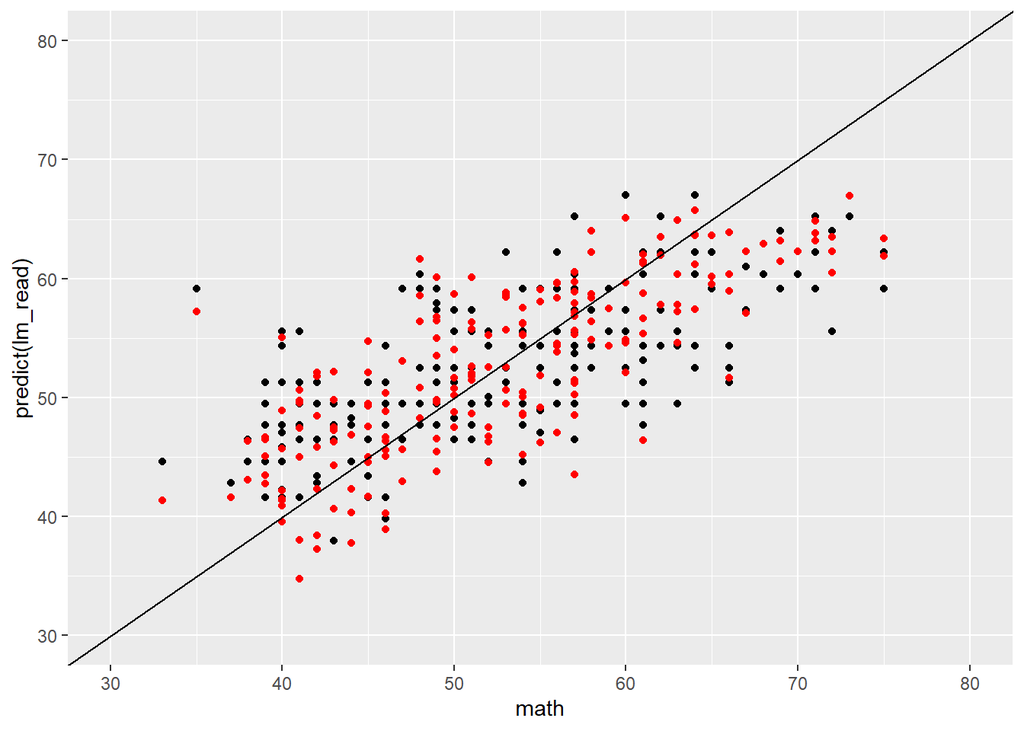

```r
ggplot(data = highschool) +
  geom_point(mapping=aes(x=math, y=predict(lm_read))) +
  geom_point(mapping=aes(x=math, y=predict(lm_all)), color="red") +
  geom_abline(intercept = 0, slope = 1) +
  xlim(30,80) +
  ylim(30,80)
```

```r
library(MASS)
```

```r
select <- dplyr::select
```

```r
# make a model which predicts price with no input variables
# effectively predicts using the mean
# the null model
model_min <- lm(math ~ 1, data=highschool )
# we can define the largest possible model using
# a dot . to mean include everything
# the full model
model_max <- lm(math ~ . , data=highschool )

scp <- list(lower = model_min, upper = model_max)

model_step <- stepAIC(model_min,
                      direction = "forward",
                      scope = scp,
                      trace=F # suppress printed output
                      )
summary(model_step)
```

```
Call:
lm(formula = math ~ read + write + science + prog, data = highschool)

Residuals:
     Min       1Q   Median       3Q      Max
-21.5628  -4.2013  -0.0933   4.4692  14.5578

Coefficients:
               Estimate Std. Error t value Pr(>|t|)
(Intercept)    12.76624    3.05519   4.179 4.43e-05 ***
read            0.24022    0.06060   3.964 0.000104 ***
write           0.20238    0.06155   3.288 0.001198 **
science         0.28403    0.05965   4.762 3.75e-06 ***
progacademic    3.80960    1.14567   3.325 0.001056 **
progvocational -0.31971    1.27768  -0.250 0.802675
---
Signif. codes:  0 '***' 0.001 '**' 0.01 '*' 0.05 '.' 0.1 ' ' 1

Residual standard error: 6.08 on 194 degrees of freedom
Multiple R-squared:  0.5895,    Adjusted R-squared:  0.5789
F-statistic: 55.71 on 5 and 194 DF,  p-value: < 2.2e-16
```

```r
model_step$anova
```

```
Stepwise Model Path
Analysis of Deviance Table

Initial Model:
math ~ 1

Final Model:
math ~ read + write + science + prog

       Step Df  Deviance Resid. Df Resid. Dev      AIC
1                              199  17465.795 895.9365
2    + read  1 7660.7590       198   9805.036 782.4668
3   + write  1 1339.5202       197   8465.516 755.0878
4 + science  1  676.2179       196   7789.298 740.4377
5    + prog  2  618.9418       194   7170.356 727.8786
```

```r
model_step_back <- stepAIC(model_max,
                           direction = "backward",
                           scope = scp,
                           trace=F # suppress printed output
                           )
summary(model_step_back)
```

```
Call:
lm(formula = math ~ prog + read + write + science, data = highschool)

Residuals:
     Min       1Q   Median       3Q      Max
-21.5628  -4.2013  -0.0933   4.4692  14.5578

Coefficients:
               Estimate Std. Error t value Pr(>|t|)
(Intercept)    12.76624    3.05519   4.179 4.43e-05 ***
progacademic    3.80960    1.14567   3.325 0.001056 **
progvocational -0.31971    1.27768  -0.250 0.802675
read            0.24022    0.06060   3.964 0.000104 ***
write           0.20238    0.06155   3.288 0.001198 **
science         0.28403    0.05965   4.762 3.75e-06 ***
---
Signif. codes:  0 '***' 0.001 '**' 0.01 '*' 0.05 '.' 0.1 ' ' 1

Residual standard error: 6.08 on 194 degrees of freedom
Multiple R-squared:  0.5895,    Adjusted R-squared:  0.5789
F-statistic: 55.71 on 5 and 194 DF,  p-value: < 2.2e-16
```

```r
model_step_back$anova
```

```
Stepwise Model Path
Analysis of Deviance Table

Initial Model:
math ~ id + race + ses + schtyp + prog + read + write + science +
    socst + gender

Final Model:
math ~ prog + read + write + science

      Step Df   Deviance Resid. Df Resid. Dev      AIC
1                              185   6857.552 736.9577
2    - ses  2   2.672073       187   6860.224 733.0356
3 - gender  1  13.043562       188   6873.268 731.4155
4  - socst  1  28.180456       189   6901.448 730.2338
5 - schtyp  1  50.279372       190   6951.728 729.6856
6     - id  1  44.965657       191   6996.693 728.9751
7   - race  3 173.662611       194   7170.356 727.8786
```

```r
model_rubbish <- lm(math~gender+socst,data=highschool)
model_step_both <- stepAIC(model_rubbish,
                      direction = "both",
                      scope = scp,
                      trace=F # supress printed output
                      )
summary(model_step_both)
```

```
Call:
lm(formula = math ~ science + prog + read + write, data = highschool)

Residuals:
     Min       1Q   Median       3Q      Max
-21.5628  -4.2013  -0.0933   4.4692  14.5578

Coefficients:
               Estimate Std. Error t value Pr(>|t|)
(Intercept)    12.76624    3.05519   4.179 4.43e-05 ***
science         0.28403    0.05965   4.762 3.75e-06 ***
progacademic    3.80960    1.14567   3.325 0.001056 **
progvocational -0.31971    1.27768  -0.250 0.802675
read            0.24022    0.06060   3.964 0.000104 ***
write           0.20238    0.06155   3.288 0.001198 **
---
Signif. codes:  0 '***' 0.001 '**' 0.01 '*' 0.05 '.' 0.1 ' ' 1

Residual standard error: 6.08 on 194 degrees of freedom
Multiple R-squared:  0.5895,    Adjusted R-squared:  0.5789
F-statistic: 55.71 on 5 and 194 DF,  p-value: < 2.2e-16
```

```r
model_step_both$anova
```

```
Stepwise Model Path
Analysis of Deviance Table

Initial Model:
math ~ gender + socst

Final Model:
math ~ science + prog + read + write

       Step Df   Deviance Resid. Df Resid. Dev      AIC
1                               197  12229.289 828.6544
2 + science  1 3096.71530       196   9132.574 772.2571
3    + prog  2 1088.23439       194   8044.340 750.8813
4    + read  1  596.08047       193   7448.259 737.4837
5   + write  1  322.44672       192   7125.813 730.6323
6   - socst  1   21.81648       193   7147.629 729.2437
7  - gender  1   22.72691       194   7170.356 727.8786
```

```r
#install.packages("leaps")
library(leaps)
```

```r
regsubsets_out <- regsubsets( math ~ . - id,
                              data = highschool,
                              nbest = 1,
                              nvmax = NULL,
                              force.in = NULL,
                              force.out = NULL,
                              method = 'exhaustive'
                              )
summary(regsubsets_out)
```

```
Subset selection object
Call: regsubsets.formula(math ~ . - id, data = highschool, nbest = 1,
    nvmax = NULL, force.in = NULL, force.out = NULL, method = "exhaustive")
13 Variables  (and intercept)
                     Forced in Forced out
raceasian                FALSE      FALSE
raceafrican-american     FALSE      FALSE
racewhite                FALSE      FALSE
sesmiddle                FALSE      FALSE
seshigh                  FALSE      FALSE
schtypprivate            FALSE      FALSE
progacademic             FALSE      FALSE
progvocational           FALSE      FALSE
read                     FALSE      FALSE
write                    FALSE      FALSE
science                  FALSE      FALSE
socst                    FALSE      FALSE
genderfemale             FALSE      FALSE
1 subsets of each size up to 13
Selection Algorithm: exhaustive
          raceasian raceafrican-american racewhite sesmiddle seshigh
1  ( 1 )  " "       " "                  " "       " "       " "
2  ( 1 )  " "       " "                  " "       " "       " "
3  ( 1 )  " "       " "                  " "       " "       " "
4  ( 1 )  " "       " "                  " "       " "       " "
5  ( 1 )  "*"       " "                  " "       " "       " "
6  ( 1 )  "*"       " "                  " "       " "       " "
7  ( 1 )  "*"       " "                  " "       " "       " "
8  ( 1 )  "*"       " "                  "*"       " "       " "
9  ( 1 )  "*"       " "                  "*"       "*"       " "
10  ( 1 ) "*"       " "                  "*"       "*"       " "
11  ( 1 ) "*"       "*"                  "*"       "*"       " "
12  ( 1 ) "*"       "*"                  "*"       "*"       "*"
13  ( 1 ) "*"       "*"                  "*"       "*"       "*"
          schtypprivate progacademic progvocational read write science socst
1  ( 1 )  " "           " "          " "            "*"  " "   " "     " "
2  ( 1 )  " "           " "          " "            "*"  "*"   " "     " "
3  ( 1 )  " "           "*"          " "            "*"  " "   "*"     " "
4  ( 1 )  " "           "*"          " "            "*"  "*"   "*"     " "
5  ( 1 )  " "           "*"          " "            "*"  "*"   "*"     " "
6  ( 1 )  " "           "*"          " "            "*"  "*"   "*"     "*"
7  ( 1 )  " "           "*"          " "            "*"  "*"   "*"     "*"
8  ( 1 )  " "           "*"          " "            "*"  "*"   "*"     "*"
9  ( 1 )  " "           "*"          " "            "*"  "*"   "*"     "*"
10  ( 1 ) "*"           "*"          " "            "*"  "*"   "*"     "*"
11  ( 1 ) "*"           "*"          " "            "*"  "*"   "*"     "*"
12  ( 1 ) "*"           "*"          " "            "*"  "*"   "*"     "*"
13  ( 1 ) "*"           "*"          "*"            "*"  "*"   "*"     "*"
          genderfemale
1  ( 1 )  " "
2  ( 1 )  " "
3  ( 1 )  " "
4  ( 1 )  " "
5  ( 1 )  " "
6  ( 1 )  " "
7  ( 1 )  "*"
8  ( 1 )  "*"
9  ( 1 )  "*"
10  ( 1 ) "*"
11  ( 1 ) "*"
12  ( 1 ) "*"
13  ( 1 ) "*"
```

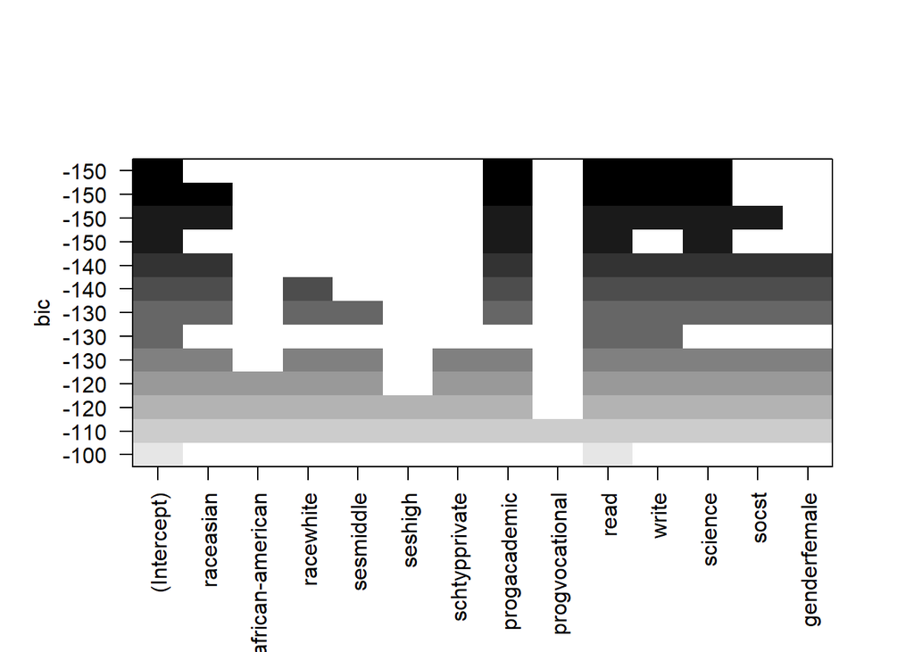

```r
plot(regsubsets_out)
```

```r
lm_regsubset <- lm(formula = math ~ prog + read + write + science, data = highschool)
summary(lm_regsubset)
```

```
Call:
lm(formula = math ~ prog + read + write + science, data = highschool)

Residuals:
     Min       1Q   Median       3Q      Max
-21.5628  -4.2013  -0.0933   4.4692  14.5578

Coefficients:
               Estimate Std. Error t value Pr(>|t|)
(Intercept)    12.76624    3.05519   4.179 4.43e-05 ***
progacademic    3.80960    1.14567   3.325 0.001056 **
progvocational -0.31971    1.27768  -0.250 0.802675
read            0.24022    0.06060   3.964 0.000104 ***
write           0.20238    0.06155   3.288 0.001198 **
science         0.28403    0.05965   4.762 3.75e-06 ***
---
Signif. codes:  0 '***' 0.001 '**' 0.01 '*' 0.05 '.' 0.1 ' ' 1

Residual standard error: 6.08 on 194 degrees of freedom
Multiple R-squared:  0.5895,    Adjusted R-squared:  0.5789
F-statistic: 55.71 on 5 and 194 DF,  p-value: < 2.2e-16
```

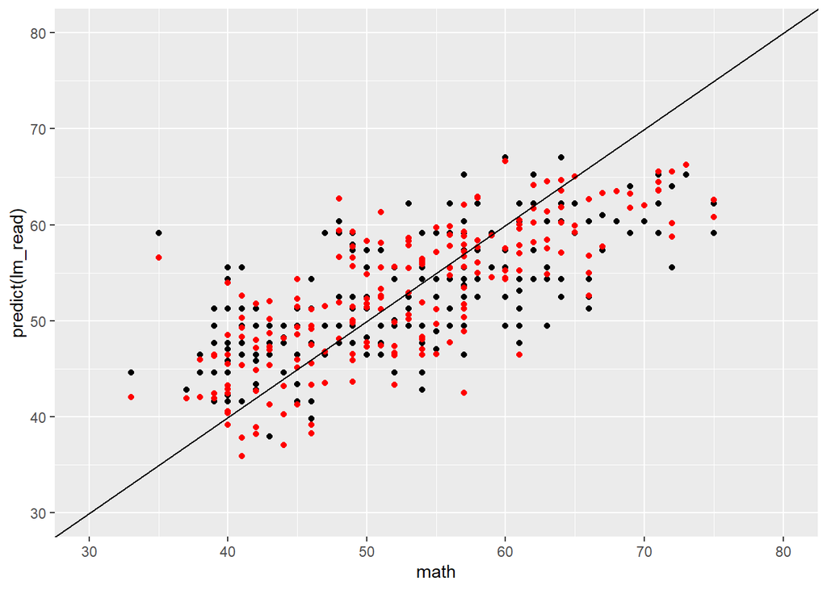

```r
ggplot(data = highschool) +
  geom_point(mapping=aes(x=math, y=predict(lm_read))) +
  geom_point(mapping=aes(x=math, y=predict(lm_regsubset)), color="red") +
  geom_abline(intercept = 0, slope = 1) +
  xlim(30,80) +
  ylim(30,80)
```

```r
highschool <- highschool %>%
  mutate(score = (read+write+science)/3, score_sq=score^2 )

lm_my_best <- lm(formula= math ~ poly(score,2) + prog, data = highschool)
summary(lm_my_best)
```

```
Call:
lm(formula = math ~ poly(score, 2) + prog, data = highschool)

Residuals:
     Min       1Q   Median       3Q      Max
-20.8747  -3.9834  -0.1935   4.1098  15.2102

Coefficients:
                Estimate Std. Error t value Pr(>|t|)
(Intercept)      50.9455     0.8933  57.029  < 2e-16 ***
poly(score, 2)1  87.0463     6.6118  13.165  < 2e-16 ***
poly(score, 2)2  15.7263     6.0055   2.619  0.00952 **
progacademic      3.5503     1.0893   3.259  0.00132 **
progvocational   -0.6577     1.2581  -0.523  0.60171
---
Signif. codes:  0 '***' 0.001 '**' 0.01 '*' 0.05 '.' 0.1 ' ' 1

Residual standard error: 5.971 on 195 degrees of freedom
Multiple R-squared:  0.602, Adjusted R-squared:  0.5938
F-statistic: 73.74 on 4 and 195 DF,  p-value: < 2.2e-16
```

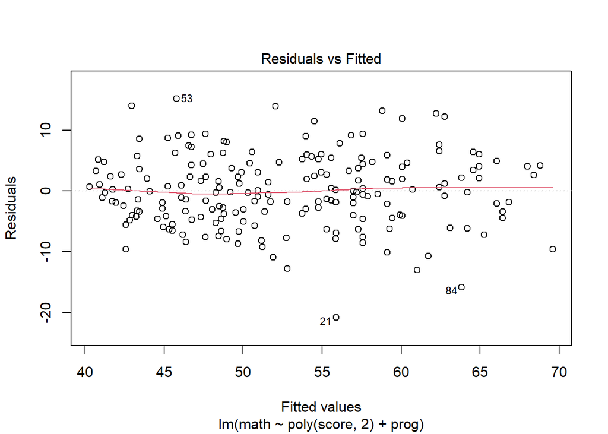

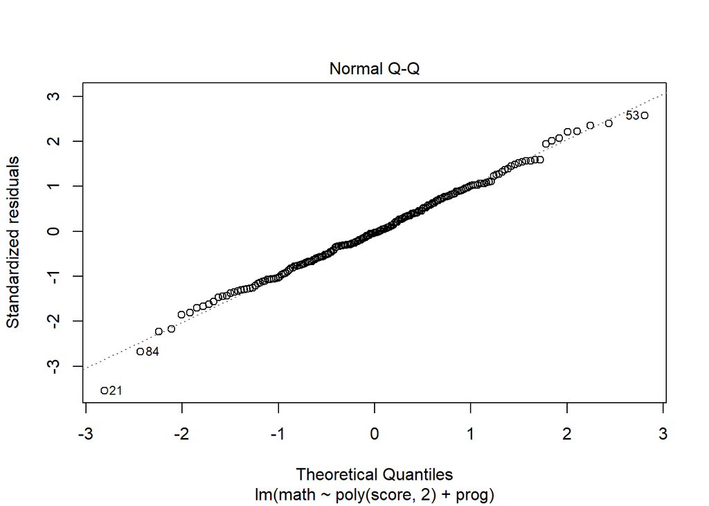

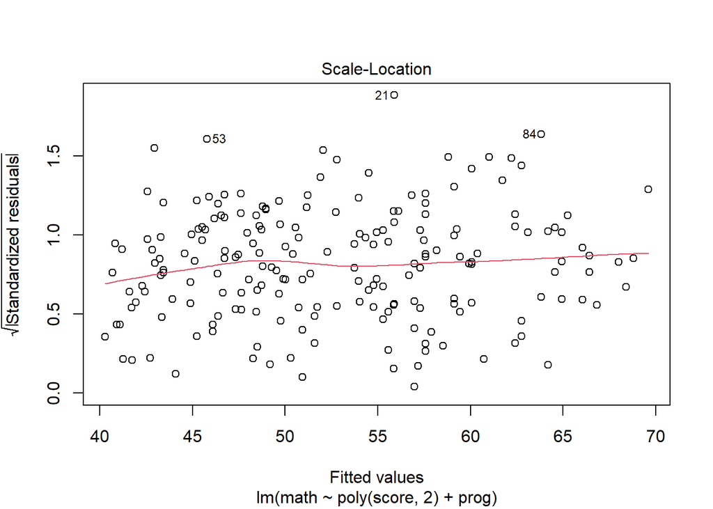

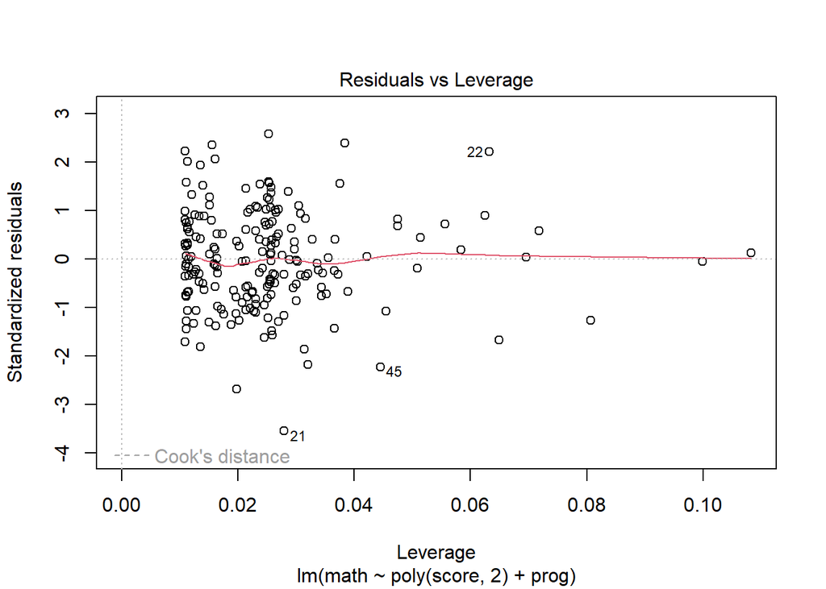

```r
plot(lm_my_best)
```

# More linear regression discussion

```r
library(tidyverse)
```

```r
female_labels <- c("male","female")
race_labels <- c("hispanic", "asian", "african-american", "white")
ses_labels <- c("low", "middle", "high")
schtyp_labels <- c("public","private")
prog_labels <- c("general", "academic", "vocational")
highschool <- read_csv("hsb2.csv", col_types = "dfffffddddd") %>%
  mutate(gender = factor(female, levels = c(0,1), labels = female_labels),
         race = factor(race, levels = c(1,2,3,4), labels = race_labels),
         ses = factor(ses, levels = c(1,2,3),labels = ses_labels),
         schtyp = factor(schtyp, levels = c(1,2), labels = schtyp_labels),
         prog = factor(prog, levels = c(1,2,3), labels = prog_labels)
         ) %>%
  select(-female)
glimpse(highschool)
```

```
Rows: 200
Columns: 11
$ id      <dbl> 70, 121, 86, 141, 172, 113, 50, 11, 84, 48, 75, 60, 95, 104, 3…
$ race    <fct> white, white, white, white, white, white, african-american, hi…
$ ses     <fct> low, middle, high, high, middle, middle, middle, middle, middl…
$ schtyp  <fct> public, public, public, public, public, public, public, public…
$ prog    <fct> general, vocational, general, vocational, academic, academic, …
$ read    <dbl> 57, 68, 44, 63, 47, 44, 50, 34, 63, 57, 60, 57, 73, 54, 45, 42…
$ write   <dbl> 52, 59, 33, 44, 52, 52, 59, 46, 57, 55, 46, 65, 60, 63, 57, 49…
$ math    <dbl> 41, 53, 54, 47, 57, 51, 42, 45, 54, 52, 51, 51, 71, 57, 50, 43…
$ science <dbl> 47, 63, 58, 53, 53, 63, 53, 39, 58, 50, 53, 63, 61, 55, 31, 50…
$ socst   <dbl> 57, 61, 31, 56, 61, 61, 61, 36, 51, 51, 61, 61, 71, 46, 56, 56…
$ gender  <fct> male, female, male, male, male, male, male, male, male, male, …
```

## Applying a multiple regression

Let’s try to predict math score based on science score and gender:

```r
model_v1 <- lm(math ~ science + gender,data=highschool)
summary(model_v1)
```

```
Call:
lm(formula = math ~ science + gender, data = highschool)

Residuals:
     Min       1Q   Median       3Q      Max
-25.5833  -5.2369   0.6198   4.6096  18.8215

Coefficients:
             Estimate Std. Error t value Pr(>|t|)
(Intercept)  21.00134    2.90036   7.241 9.78e-12 ***
science       0.59973    0.05252  11.418  < 2e-16 ***
genderfemale  0.98863    1.04545   0.946    0.345
---
Signif. codes:  0 '***' 0.001 '**' 0.01 '*' 0.05 '.' 0.1 ' ' 1

Residual standard error: 7.301 on 197 degrees of freedom
Multiple R-squared:  0.3988,    Adjusted R-squared:  0.3927
F-statistic: 65.33 on 2 and 197 DF,  p-value: < 2.2e-16
```

The result is a fit formula:

$$[mathscore] = 21.00 + 0.60 \times [science score] + 0.99
\times 1\lbrace gender = female\rbrace$$

where $1\lbrace gender = female\rbrace = 1$ for female, $1\lbrace gender = female\rbrace = 0$ for males, is what is known as an indicator function.

This is equivalent to the result:

**Prediction formula for females:**

$$[math\ score] = 21.00 + 0.60 × [science\ score] + 0.99 \times 1 \\
= 21.99 + 0.60 × [science\ score]$$

- In this way we see that being female adds $0.99$ marks to the predicted grade relative to being a male.
- We can manually add these lines of best fit to a plot using ggplot’s `geom_abline` which adds a line of a given intercept $a$ and gradient $b$.

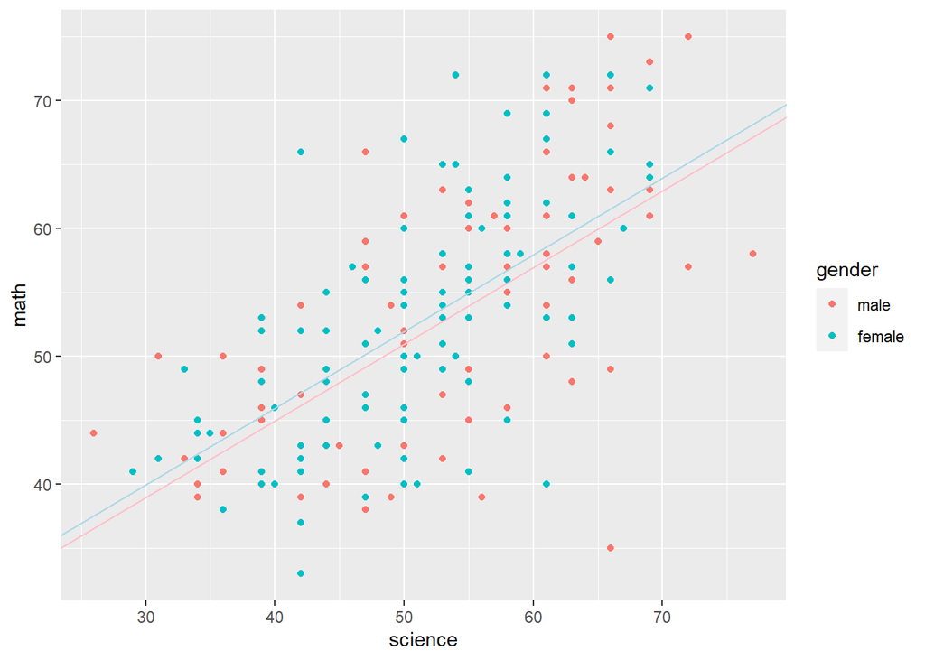

```r
highschool %>%
  ggplot(mapping = aes(y=math, x=science, color=gender)) +
  geom_point()+
  geom_abline(intercept=21.99, slope=0.60, color="lightblue") +
  geom_abline(intercept=20.99, slope=0.60, color="pink")
```

- Note that alternatively we can use predict to calculate fitted predictions automatically.
- To do this we generate new dataframes, formatted as the original dataframe but with the values we want to use as input predictions.

```r
# note we must match the factor format of the gender column
# so add in the relevant mutate function call
highschool_f_demo <- tibble( science = seq(0,100,0.1), gender = "female") %>%
mutate(gender = factor(gender, levels=c("male","female")))
highschool_m_demo <- tibble( science = seq(0,100,0.1), gender = "male") %>%
mutate(gender = factor(gender, levels=c("male","female")))
highschool_f_demo$math <- predict(model_v1, newdata = highschool_f_demo)
highschool_m_demo$math <- predict(model_v1, newdata = highschool_m_demo)
```

- Now we have two dataframes with science scores running from 0 to 100, with female and male gender respectively along with predicted math columns.
- This then makes it easy to plot the results (note we set the default mapping in the ggplot command on the first line):

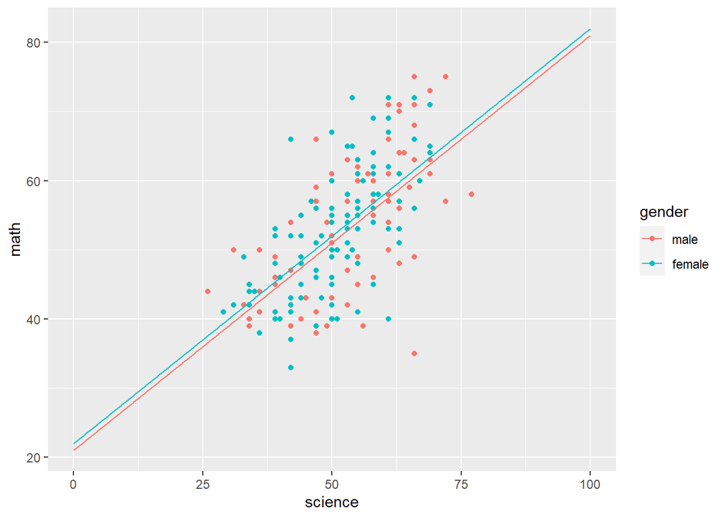

```r
ggplot(mapping = aes(y=math, x=science, color=gender)) +
  geom_point(data = highschool) +
  geom_line(data = highschool_m_demo) +
  geom_line(data = highschool_f_demo)
```

- We see that in this model the effect of gender (adding $0.99$ to prediction for females) is independent of the science score.
- We can make a second model where we add formula term `gender*science` to allow an interaction term between gender and science score.

```r
model_v2 <- lm(math ~ science + gender + gender*science,data=highschool)
summary(model_v2)
```

```
Call:
lm(formula = math ~ science + gender + gender * science, data = highschool)

Residuals:
     Min       1Q   Median       3Q      Max
-24.8912  -4.9295   0.3148   4.2671  19.3840

Coefficients:
                     Estimate Std. Error t value Pr(>|t|)
(Intercept)           23.8960     3.8688   6.177 3.71e-09 ***
science                0.5454     0.0712   7.660 8.36e-13 ***
genderfemale          -5.1848     5.5644  -0.932    0.353
science:genderfemale   0.1190     0.1054   1.130    0.260
---
Signif. codes:  0 '***' 0.001 '**' 0.01 '*' 0.05 '.' 0.1 ' ' 1

Residual standard error: 7.296 on 196 degrees of freedom
Multiple R-squared:  0.4027,    Adjusted R-squared:  0.3935
F-statistic: 44.04 on 3 and 196 DF,  p-value: < 2.2e-16
```

The result is a fit formula:

$$[math\ score] = 23.89 + 0.55 \times [science\ score] −$$

$$5.18 \times 1\lbrace gender = female \rbrace + 0.11 \times 1\lbrace gender = female\rbrace \times [science\ score]$$

This is equivalent to the result:

**Prediction formula for males:**

$$= 23.89 + 0.55 \times [science\ score]$$

**Prediction formula for females:**

$$[math\ score] = 23.89 + 0.55 \times [science\ score] - 5.18 \times 1 + 0.11 \times 1 \times [science\ score]$$

$$= (23.89 - 5.18) + (0.55 + 0.11) \times [science\ score] \\
= 18.71 + 0.66 \times [science\ score]$$

We can copy the code above to plot the predictions for males and females over a range of science scores:

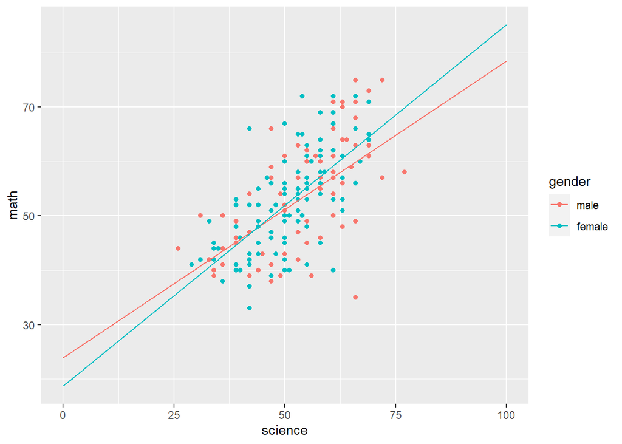

```r
highschool_f_demo <- tibble( science = seq(0,100,0.1), gender = "female") %>%
  mutate(gender = factor(gender, levels=c("male","female")))
highschool_m_demo <- tibble( science = seq(0,100,0.1), gender = "male") %>%
  mutate(gender = factor(gender, levels=c("male","female")))

highschool_f_demo$math <- predict(model_v2, newdata = highschool_f_demo)
highschool_m_demo$math <- predict(model_v2, newdata = highschool_m_demo)

ggplot(mapping = aes(y=math, x=science, color=gender)) +
  geom_point(data = highschool) +
  geom_line(data = highschool_m_demo) +
  geom_line(data = highschool_f_demo)
```

- We can see that when we have an interaction between a numerical and categorical variables we are allowing the slope of the fitted lines to be category dependent.
- In this case we should consider the statistical significance of the difference between the modelled fit between male and female scores.
- In this case the cofficients associated with gender (and the interaction term between gender and science score) have p-values above $0.05$, the $95\%$ significance level.
- **This means from this analysis we would conclude that we cannot reject the null hypothesis that when science score is used to predict math scores gender has no influence.**

## Alternative way to view results

- An alternative way to view the results of a model is to plot fitted predictions vs actual values To do this we can use the `predict` function to add a `..._pred` column to our data for plotting.
- If the predictions were perfect, then all the data points would lie on the line $y=x$ and the distance (vertical distance if we put predicted values on the $y$-axis and vice versa) from each point to this line show us the size of the residuals.

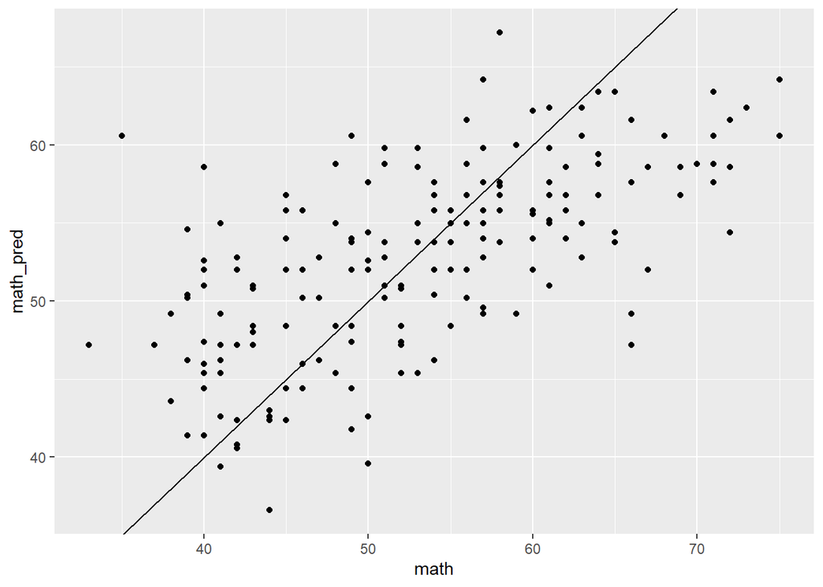

```r
highschool$math_pred <- predict(model_v1, newdata=highschool)

highschool %>% ggplot() +
  geom_point(mapping = aes(y=math_pred, x=math)) +
  geom_abline(intercept=0, slope=1)
```

- We can see if a full model reduces the residuals. (Note we must exclude the prediction column from the model).

```r
model_full <- lm(math ~ . - math_pred, data=highschool)
summary(model_full)
```

```
Call:
lm(formula = math ~ . - math_pred, data = highschool)

Residuals:
     Min       1Q   Median       3Q      Max
-22.2553  -4.0316  -0.2929   4.7013  14.5877

Coefficients:
                     Estimate Std. Error t value Pr(>|t|)
(Intercept)          11.97130    3.33606   3.588 0.000426 ***
id                    0.02296    0.01654   1.389 0.166654
raceasian             4.25082    2.34550   1.812 0.071557 .
raceafrican-american -0.96673    1.95298  -0.495 0.621185
racewhite            -1.91976    2.31956  -0.828 0.408941
sesmiddle             0.31934    1.19143   0.268 0.788973
seshigh               0.22222    1.34901   0.165 0.869340
schtypprivate        -1.69971    1.61058  -1.055 0.292644
progacademic          3.70713    1.18212   3.136 0.001993 **
progvocational       -0.04816    1.32694  -0.036 0.971087
read                  0.24803    0.06755   3.672 0.000315 ***
write                 0.18103    0.07288   2.484 0.013880 *
science               0.25177    0.06597   3.817 0.000184 ***
socst                 0.04722    0.05892   0.801 0.423928
genderfemale         -0.54883    0.98497  -0.557 0.578062
---
Signif. codes:  0 '***' 0.001 '**' 0.01 '*' 0.05 '.' 0.1 ' ' 1

Residual standard error: 6.088 on 185 degrees of freedom
Multiple R-squared:  0.6074,    Adjusted R-squared:  0.5777
F-statistic: 20.44 on 14 and 185 DF,  p-value: < 2.2e-16
```

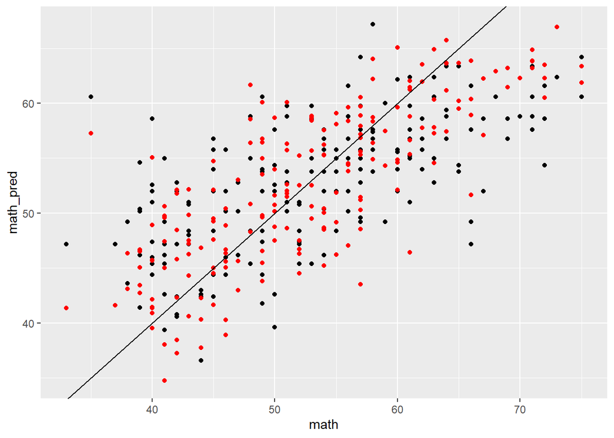

```r
highschool$math_pred_full <- predict(model_full, newdata=highschool)

highschool %>% ggplot() +
  geom_point(mapping = aes(y=math_pred, x=math)) +
  geom_point(mapping = aes(y=math_pred_full, x=math), color="red") +
  geom_abline(intercept=0, slope=1)
```

- In this case there is perhaps a small reduction in the residuals (red points are closer to the line in the vertical direction, than the black points), but it is not a huge amount.

## Non-linear fit functions

We saw in our real estate data a clear sign that the relationship between price and house age could not be described by a straight line:

```r
real_estate <- read_csv("real_estate.csv") %>%
  filter(price_per_sqm < 100)
```

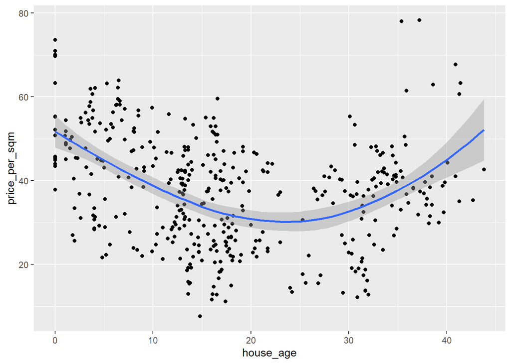

```r
real_estate %>%
  ggplot(mapping = aes(y=price_per_sqm, x=house_age)) +
  geom_point() +
  geom_smooth()
```

In this case, we might expect better predictions if we fit the relationship with a polynomial curve, rather than a straight line.

We saw to make a straight line regression we can use the following code:

```r
model_linear <- lm(price_per_sqm ~ house_age , data=real_estate)
summary(model_linear)
```

```
Call:
lm(formula = price_per_sqm ~ house_age, data = real_estate)

Residuals:
    Min      1Q  Median      3Q     Max
-30.895 -10.502   1.837   8.227  45.213

Coefficients:
            Estimate Std. Error t value Pr(>|t|)
(Intercept) 42.06794    1.16255  36.186  < 2e-16 ***
house_age   -0.24142    0.05517  -4.376 1.54e-05 ***
---
Signif. codes:  0 '***' 0.001 '**' 0.01 '*' 0.05 '.' 0.1 ' ' 1

Residual standard error: 12.77 on 411 degrees of freedom
Multiple R-squared:  0.04451,   Adjusted R-squared:  0.04219
F-statistic: 19.15 on 1 and 411 DF,  p-value: 1.536e-05
```

To fit using a quadratic, or 2nd order polynomial, we can use:

```r
# 2nd order polynomial fit of price_per_sqm against house_age
model_poly2 <- lm(price_per_sqm ~ poly(house_age,2) , data=real_estate)
summary(model_poly2)
```

```
Call:
lm(formula = price_per_sqm ~ poly(house_age, 2), data = real_estate)

Residuals:
    Min      1Q  Median      3Q     Max
-26.252  -9.050  -0.269   8.418  39.918

Coefficients:
                    Estimate Std. Error t value Pr(>|t|)
(Intercept)           37.788      0.568  66.525  < 2e-16 ***
poly(house_age, 2)1  -55.870     11.543  -4.840 1.84e-06 ***
poly(house_age, 2)2  111.209     11.543   9.634  < 2e-16 ***
---
Signif. codes:  0 '***' 0.001 '**' 0.01 '*' 0.05 '.' 0.1 ' ' 1

Residual standard error: 11.54 on 410 degrees of freedom
Multiple R-squared:  0.2209,    Adjusted R-squared:  0.2171
F-statistic: 58.12 on 2 and 410 DF,  p-value: < 2.2e-16
```

- The coefficients here are for the linear (1st order polynomial) component and the quadratic (2nd order polynomial) component.
- If we fit a polynomial and find the coefficient of the highest polynomial term is not significant (p-value > chosen significance level), then we can say that there is no evidence that that our regression function requires a term of that order.
- In this case the 2nd order term is statistically significant, reflecting the fact that a quadratic curve better fits the relationship.

Next, we can extend the fit to a cubic (3rd order polynomial curve):

```r
model_poly3 <- lm(price_per_sqm ~ poly(house_age,3) , data=real_estate)
summary(model_poly3)
```

```
Call:
lm(formula = price_per_sqm ~ poly(house_age, 3), data = real_estate)

Residuals:
    Min      1Q  Median      3Q     Max
-26.554  -8.766  -0.006   8.174  40.079

Coefficients:
                    Estimate Std. Error t value Pr(>|t|)
(Intercept)           37.788      0.568  66.523  < 2e-16 ***
poly(house_age, 3)1  -55.870     11.544  -4.840 1.85e-06 ***
poly(house_age, 3)2  111.209     11.544   9.634  < 2e-16 ***
poly(house_age, 3)3   11.378     11.544   0.986    0.325
---
Signif. codes:  0 '***' 0.001 '**' 0.01 '*' 0.05 '.' 0.1 ' ' 1

Residual standard error: 11.54 on 409 degrees of freedom
Multiple R-squared:  0.2227,    Adjusted R-squared:  0.217
F-statistic: 39.07 on 3 and 409 DF,  p-value: < 2.2e-16
```

- In this case, we find the additional coefficient is not significantly different from zero, so there is no statistical evidence that a cubic curve is required to fit the true regression function in this case.
- As the linear model is nested within the quadratic model, which itself is nested within the cubic model, we can also compare using the `anova` function to see if the reduction in variance (size of the residuals) compared between the models is significant.
- We find that only the improvement from adding the quadratic term is statistically significant:

```r
anova(model_linear, model_poly2, model_poly3)
```

```
Analysis of Variance Table

Model 1: price_per_sqm ~ house_age
Model 2: price_per_sqm ~ poly(house_age, 2)
Model 3: price_per_sqm ~ poly(house_age, 3)
  Res.Df   RSS Df Sum of Sq       F Pr(>F)
1    411 67001
2    410 54634  1   12367.5 92.8054 <2e-16 ***
3    409 54504  1     129.5  0.9714 0.3249
---
Signif. codes:  0 '***' 0.001 '**' 0.01 '*' 0.05 '.' 0.1 ' ' 1
```

We can use the predict method as above to draw the different fit functions:

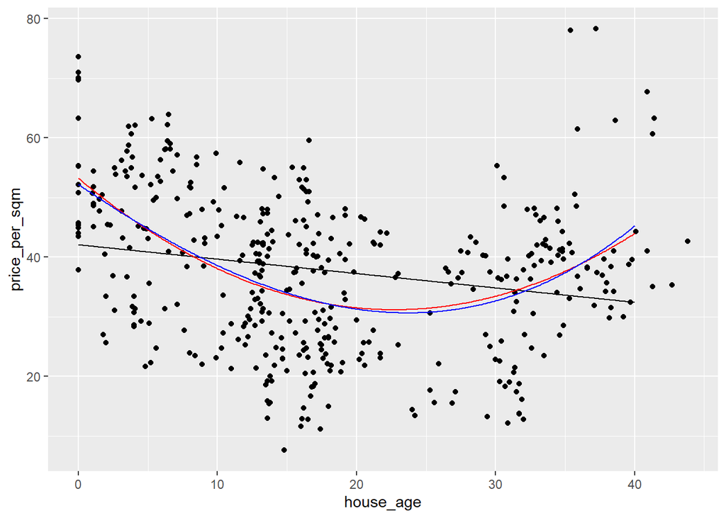

```r
real_estate_new <- tibble(house_age = seq(0,40,0.1))

real_estate_new$price_per_sqm_linear <- predict(model_linear, newdata = real_estate_new)
real_estate_new$price_per_sqm_poly2 <- predict(model_poly2, newdata = real_estate_new)
real_estate_new$price_per_sqm_poly3 <- predict(model_poly3, newdata = real_estate_new)

ggplot() +
  geom_point(data=real_estate,
             mapping=aes(x=house_age, y=price_per_sqm)
             ) +
  geom_line(data=real_estate_new,
            mapping=aes(x=house_age, y=price_per_sqm_linear),
            color="black",
            ) +
  geom_line(data=real_estate_new,
            mapping=aes(x=house_age, y=price_per_sqm_poly2),
            color="red"
            ) +
  geom_line(data=real_estate_new,
            mapping=aes(x=house_age, y=price_per_sqm_poly3),
            color="blue")
```

```r
model_new <- lm(price_per_sqm ~ latitude +
                  sale_date +
                  dist_to_transport +
                  num_stores +
                  poly(house_age,2),
                data=real_estate)
summary(model_new)
```

```
Call:
lm(formula = price_per_sqm ~ latitude + sale_date + dist_to_transport +
    num_stores + poly(house_age, 2), data = real_estate)

Residuals:
    Min      1Q  Median      3Q     Max
-32.406  -4.883  -0.379   4.638  31.407

Coefficients:
                      Estimate Std. Error t value Pr(>|t|)
(Intercept)         -1.603e+04  2.771e+03  -5.786 1.44e-08 ***
latitude             2.335e+02  3.779e+01   6.180 1.56e-09 ***
sale_date            5.085e+00  1.331e+00   3.821 0.000154 ***
dist_to_transport   -3.402e-03  4.298e-04  -7.915 2.39e-14 ***
num_stores           1.198e+00  1.614e-01   7.423 6.78e-13 ***
poly(house_age, 2)1 -6.095e+01  7.609e+00  -8.010 1.22e-14 ***
poly(house_age, 2)2  5.791e+01  8.025e+00   7.216 2.65e-12 ***
---
Signif. codes:  0 '***' 0.001 '**' 0.01 '*' 0.05 '.' 0.1 ' ' 1

Residual standard error: 7.56 on 406 degrees of freedom
Multiple R-squared:  0.6691,    Adjusted R-squared:  0.6642
F-statistic: 136.8 on 6 and 406 DF,  p-value: < 2.2e-16
```